# Project Title : Analyzing and Enhancing the Quality of Vinho Verde Wine

**Student Name: Rafat Shahriar**

**Objectives:** Understanding Factors: Unravel the physicochemical attributes influencing Vinho Verde wine quality. Quality Prediction: Develop predictive models based on these attributes for quality estimation and enhancement.

**Beneficiaries:** This project targets winemakers and vineyard managers, providing insights to optimize production processes and consistently elevate wine quality.

**Expected Benefits:**

1. Precision in Production: Refine processes for consistent, high-quality wine.
2. Data-Driven Refinement: Guide vineyard practices for optimal grape quality.
3. Market Differentiation: Position wineries as premium producers in the market.

**Relevance:** This exploration is crucial for aligning wine quality with consumer expectations and promoting sustainable practices in winemaking.

**Industry Impact:** The project aims to set quality benchmarks, inspire innovation, and contribute to industry-wide excellence.

**Future Directions:** Laying the groundwork for potential future analyses, such as exploring regional influences on wine quality.

## Data

**Data Source:** The dataset is obtained from Cortez et al., 2009. It contains physicochemical variables like fixed acidity, volatile acidity, etc., and sensory variable quality. (Source URL: https://www.kaggle.com/datasets/uciml/red-wine-quality-cortez-et-al-2009/code?datasetId=4458)

> **Variables:**
1. Fixed Acidity (Numeric): Represents the fixed (non-volatile) acids in the wine.
2. Volatile Acidity (Numeric): Indicates the amount of acetic acid in the wine, which can contribute to an unpleasant vinegar taste.
3. Citric Acid (Numeric):Represents the amount of citric acid in the wine, contributing to freshness and flavor.
4. Residual Sugar (Numeric):Represents the amount of sugar remaining after fermentation, influencing sweetness.
5. Chlorides (Numeric):Indicates the amount of salt in the wine, affecting taste and stability.
6. Free Sulfur Dioxide (Numeric):Represents the free form of sulfur dioxide, which prevents microbial growth and oxidation.
7. Total Sulfur Dioxide (Numeric):Represents the total amount of sulfur dioxide, including both free and bound forms.
8. Density (Numeric):Represents the density of the wine, related to alcohol content and sweetness.
9. pH (Numeric):Represents the acidity or basicity of the wine.
10. Sulphates (Numeric): Represents the amount of sulfur dioxide in the wine, contributing to antimicrobial and antioxidant properties.
11. Alcohol (Numeric):Represents the alcohol content of the wine.
12. Quality (Numeric):Represents the sensory output variable, indicating the quality of the wine.

```python
## set up the environments
import pandas as pd
import matplotlib.pyplot as plt
import seaborn as sns
from sklearn.model_selection import train_test_split
from sklearn.linear_model import LinearRegression
from sklearn.metrics import mean_squared_error
from sklearn.cluster import KMeans
import numpy as np
from sklearn.ensemble import RandomForestRegressor
from sklearn.tree import DecisionTreeRegressor
from sklearn.svm import SVR
from sklearn.neighbors import KNeighborsRegressor
from sklearn.metrics import mean_absolute_error, r2_score
```

```python
# Loading the dataset
url = r"C:\Users\rshah\Downloads\MIS Final project\winequality-red.csv"
wine = pd.read_csv(url)
wine
```

|  | fixed acidity | volatile acidity | citric acid | residual sugar | chlorides | free sulfur dioxide | total sulfur dioxide | density | pH | sulphates | alcohol | quality |
| --- | --- | --- | --- | --- | --- | --- | --- | --- | --- | --- | --- | --- |
| 0 | 7.4 | 0.700 | 0.00 | 1.9 | 0.076 | 11.0 | 34.0 | 0.99780 | 3.51 | 0.56 | 9.4 | 5 |
| 1 | 7.8 | 0.880 | 0.00 | 2.6 | 0.098 | 25.0 | 67.0 | 0.99680 | 3.20 | 0.68 | 9.8 | 5 |
| 2 | 7.8 | 0.760 | 0.04 | 2.3 | 0.092 | 15.0 | 54.0 | 0.99700 | 3.26 | 0.65 | 9.8 | 5 |
| 3 | 11.2 | 0.280 | 0.56 | 1.9 | 0.075 | 17.0 | 60.0 | 0.99800 | 3.16 | 0.58 | 9.8 | 6 |
| 4 | 7.4 | 0.700 | 0.00 | 1.9 | 0.076 | 11.0 | 34.0 | 0.99780 | 3.51 | 0.56 | 9.4 | 5 |
| ... | ... | ... | ... | ... | ... | ... | ... | ... | ... | ... | ... | ... |
| 1594 | 6.2 | 0.600 | 0.08 | 2.0 | 0.090 | 32.0 | 44.0 | 0.99490 | 3.45 | 0.58 | 10.5 | 5 |
| 1595 | 5.9 | 0.550 | 0.10 | 2.2 | 0.062 | 39.0 | 51.0 | 0.99512 | 3.52 | 0.76 | 11.2 | 6 |
| 1596 | 6.3 | 0.510 | 0.13 | 2.3 | 0.076 | 29.0 | 40.0 | 0.99574 | 3.42 | 0.75 | 11.0 | 6 |
| 1597 | 5.9 | 0.645 | 0.12 | 2.0 | 0.075 | 32.0 | 44.0 | 0.99547 | 3.57 | 0.71 | 10.2 | 5 |
| 1598 | 6.0 | 0.310 | 0.47 | 3.6 | 0.067 | 18.0 | 42.0 | 0.99549 | 3.39 | 0.66 | 11.0 | 6 |

1599 rows × 12 columns

```python
# Displaying basic information
wine.info()
```

```
<class 'pandas.core.frame.DataFrame'>
RangeIndex: 1599 entries, 0 to 1598
Data columns (total 12 columns):
 #   Column                Non-Null Count  Dtype
---  ------                --------------  -----
 0   fixed acidity         1599 non-null   float64
 1   volatile acidity      1599 non-null   float64
 2   citric acid           1599 non-null   float64
 3   residual sugar        1599 non-null   float64
 4   chlorides             1599 non-null   float64
 5   free sulfur dioxide   1599 non-null   float64
 6   total sulfur dioxide  1599 non-null   float64
 7   density               1599 non-null   float64
 8   pH                    1599 non-null   float64
 9   sulphates             1599 non-null   float64
 10  alcohol               1599 non-null   float64
 11  quality               1599 non-null   int64
dtypes: float64(11), int64(1)
memory usage: 150.0 KB
```

```python
#Exploring basic statistics
wine.describe()
```

|  | fixed acidity | volatile acidity | citric acid | residual sugar | chlorides | free sulfur dioxide | total sulfur dioxide | density | pH | sulphates | alcohol | quality |
| --- | --- | --- | --- | --- | --- | --- | --- | --- | --- | --- | --- | --- |
| count | 1599.000000 | 1599.000000 | 1599.000000 | 1599.000000 | 1599.000000 | 1599.000000 | 1599.000000 | 1599.000000 | 1599.000000 | 1599.000000 | 1599.000000 | 1599.000000 |
| mean | 8.319637 | 0.527821 | 0.270976 | 2.538806 | 0.087467 | 15.874922 | 46.467792 | 0.996747 | 3.311113 | 0.658149 | 10.422983 | 5.636023 |
| std | 1.741096 | 0.179060 | 0.194801 | 1.409928 | 0.047065 | 10.460157 | 32.895324 | 0.001887 | 0.154386 | 0.169507 | 1.065668 | 0.807569 |
| min | 4.600000 | 0.120000 | 0.000000 | 0.900000 | 0.012000 | 1.000000 | 6.000000 | 0.990070 | 2.740000 | 0.330000 | 8.400000 | 3.000000 |
| 25% | 7.100000 | 0.390000 | 0.090000 | 1.900000 | 0.070000 | 7.000000 | 22.000000 | 0.995600 | 3.210000 | 0.550000 | 9.500000 | 5.000000 |
| 50% | 7.900000 | 0.520000 | 0.260000 | 2.200000 | 0.079000 | 14.000000 | 38.000000 | 0.996750 | 3.310000 | 0.620000 | 10.200000 | 6.000000 |
| 75% | 9.200000 | 0.640000 | 0.420000 | 2.600000 | 0.090000 | 21.000000 | 62.000000 | 0.997835 | 3.400000 | 0.730000 | 11.100000 | 6.000000 |
| max | 15.900000 | 1.580000 | 1.000000 | 15.500000 | 0.611000 | 72.000000 | 289.000000 | 1.003690 | 4.010000 | 2.000000 | 14.900000 | 8.000000 |

```python
# Check for missing values
print(wine.isnull().sum())
```

```
fixed acidity           0
volatile acidity        0
citric acid             0
residual sugar          0
chlorides               0
free sulfur dioxide     0
total sulfur dioxide    0
density                 0
pH                      0
sulphates               0
alcohol                 0
quality                 0
dtype: int64
```

### Data Analysis Sub-section (6 Questions)

1. What is the average alcohol content in the dataset?

```python
average_alcohol = wine['alcohol'].mean()
print(f"The average alcohol content is: {average_alcohol}")
```

```
The average alcohol content is: 10.422983114446529
```

1. What is the correlation between citric acid and pH?

```python
correlation_citric_ph = wine['citric acid'].corr(wine['pH'])
print(f"The correlation between citric acid and pH is: {correlation_citric_ph}")
```

```
The correlation between citric acid and pH is: -0.5419041447395097
```

1. What is the maximum residual sugar content in the dataset?

```python
max_residual_sugar = wine['residual sugar'].max()
print(f"The maximum residual sugar content is: {max_residual_sugar}")
```

```
The maximum residual sugar content is: 15.5
```

1. What is the average quality rating for wines with low volatile acidity (e.g., below 0.3)?

```python
average_quality_low_va = wine[wine['volatile acidity'] < 0.3]['quality'].mean()
print(f"The average quality for wines with low volatile acidity is: {average_quality_low_va}")
```

```
The average quality for wines with low volatile acidity is: 6.196850393700787
```

1. How many wines have a quality rating above 7?

```python
high_quality_wines = wine[wine['quality'] > 7]
count_high_quality = high_quality_wines.shape[0]
print(f"The number of wines with a quality rating above 7 is: {count_high_quality}")
```

```
The number of wines with a quality rating above 7 is: 18
```

1. Is there a relationship between density and alcohol content?

```python
relationship_density_alcohol = wine['density'].corr(wine['alcohol'])
print(f"The relationship between density and alcohol content is: {relationship_density_alcohol}")
```

```
The relationship between density and alcohol content is: -0.4961797702417019
```

## Data Visualization Sub-section

1. Scatter Plot: Alcohol Content vs. Quality

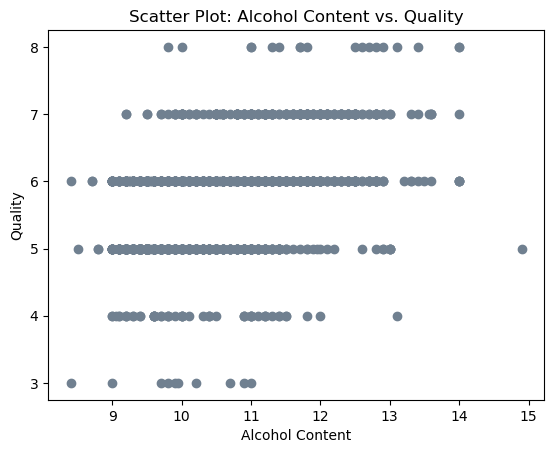

```python
plt.scatter(wine['alcohol'], wine['quality'], color='slategray')
plt.title('Scatter Plot: Alcohol Content vs. Quality')
plt.xlabel('Alcohol Content')
plt.ylabel('Quality')
plt.show()
```

1. Histogram: Distribution of pH Values

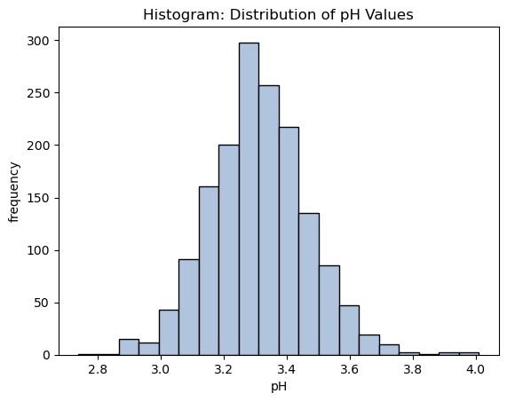

```python
plt.hist(wine['pH'], bins=20, color='lightsteelblue', edgecolor='black')
plt.title('Histogram: Distribution of pH Values')
plt.xlabel('pH')
plt.ylabel('frequency')
plt.show()
```

1. Boxplot: Total Sulfur Dioxide by Quality

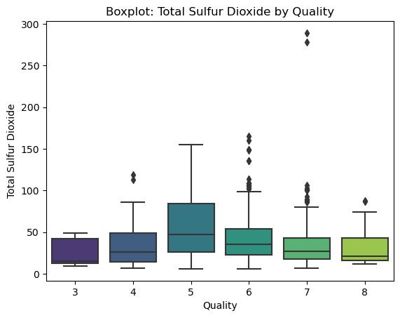

```python
sns.boxplot(x='quality', y='total sulfur dioxide', data=wine, palette='viridis')
plt.title('Boxplot: Total Sulfur Dioxide by Quality')
plt.xlabel('Quality')
plt.ylabel('Total Sulfur Dioxide')
plt.show()
```

1. Stacked Bar Chart: Quality Distribution by Citric Acid Levels

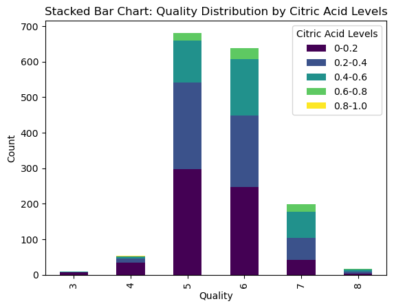

```python
bins = [0, 0.2, 0.4, 0.6, 0.8, 1.0]
labels = ['0-0.2', '0.2-0.4', '0.4-0.6', '0.6-0.8', '0.8-1.0']
wine['Citric Acid Levels'] = pd.cut(wine['citric acid'], bins=bins, labels=labels, include_lowest=True)

quality_citric_acid = wine.groupby(['quality', 'Citric Acid Levels']).size().unstack()
quality_citric_acid.plot(kind='bar', stacked=True, colormap='viridis')
plt.title('Stacked Bar Chart: Quality Distribution by Citric Acid Levels')
plt.xlabel('Quality')
plt.ylabel('Count')
plt.show()
```

## Linear Regression Analysis for Wine Quality Prediction

```python
wine = wine.drop(['Citric Acid Levels'], axis=1)
```

```python
X = wine.drop("quality", axis=1)
y = wine["quality"]

test_sizes = [0.5, 0.4, 0.3, 0.25, 0.2]

regressors = {
    "Decision Tree": DecisionTreeRegressor(),
    "Random Forest": RandomForestRegressor(),
    "Linear Regression": LinearRegression(),
    "K-Nearest Neighbors": KNeighborsRegressor(),
    "Support Vector Machine": SVR(),
}

for test_size in test_sizes:
    X_train, X_test, y_train, y_test = train_test_split(X, y, test_size=test_size, random_state=0)

    for reg_name, regressor in regressors.items():
        model = regressor.fit(X_train, y_train)
        pred_y = model.predict(X_test)

        mse = mean_squared_error(y_test, pred_y)
        rmse = np.sqrt(mse)
        r_squared = r2_score(y_test, pred_y)

        print(f"For {test_size:.0%} testing data (significant variables) using {reg_name}:")
        print(f"  Mean Squared Error: {mse:.4f}")
        print(f"  Root Mean Squared Error: {rmse:.4f}")
        print(f"  Mean Absolute Error: {mean_absolute_error(y_test, pred_y):.4f}")
        print(f"  R-squared: {r_squared:.4f}")
        print("------------------------------------------------------")
```

```
For 50% testing data (significant variables) using Decision Tree:
  Mean Squared Error: 0.6538
  Root Mean Squared Error: 0.8085
  Mean Absolute Error: 0.5062
  R-squared: -0.0667
------------------------------------------------------
For 50% testing data (significant variables) using Random Forest:
  Mean Squared Error: 0.3822
  Root Mean Squared Error: 0.6183
  Mean Absolute Error: 0.4571
  R-squared: 0.3763
------------------------------------------------------
For 50% testing data (significant variables) using Linear Regression:
  Mean Squared Error: 0.4282
  Root Mean Squared Error: 0.6544
  Mean Absolute Error: 0.5073
  R-squared: 0.3014
------------------------------------------------------
For 50% testing data (significant variables) using K-Nearest Neighbors:
  Mean Squared Error: 0.5656
  Root Mean Squared Error: 0.7521
  Mean Absolute Error: 0.5900
  R-squared: 0.0772
------------------------------------------------------
For 50% testing data (significant variables) using Support Vector Machine:
  Mean Squared Error: 0.5399
  Root Mean Squared Error: 0.7348
  Mean Absolute Error: 0.5484
  R-squared: 0.1192
------------------------------------------------------
For 40% testing data (significant variables) using Decision Tree:
  Mean Squared Error: 0.6359
  Root Mean Squared Error: 0.7975
  Mean Absolute Error: 0.4797
  R-squared: -0.0675
------------------------------------------------------
For 40% testing data (significant variables) using Random Forest:
  Mean Squared Error: 0.3844
  Root Mean Squared Error: 0.6200
  Mean Absolute Error: 0.4445
```

[output cut: 95 more lines]

```
  Mean Absolute Error: 0.4696
  R-squared: 0.3284
------------------------------------------------------
For 20% testing data (significant variables) using K-Nearest Neighbors:
  Mean Squared Error: 0.5342
  Root Mean Squared Error: 0.7309
  Mean Absolute Error: 0.5687
  R-squared: 0.0667
------------------------------------------------------
For 20% testing data (significant variables) using Support Vector Machine:
  Mean Squared Error: 0.4743
  Root Mean Squared Error: 0.6887
  Mean Absolute Error: 0.5187
  R-squared: 0.1715
------------------------------------------------------
```

- Visualizing the predictions

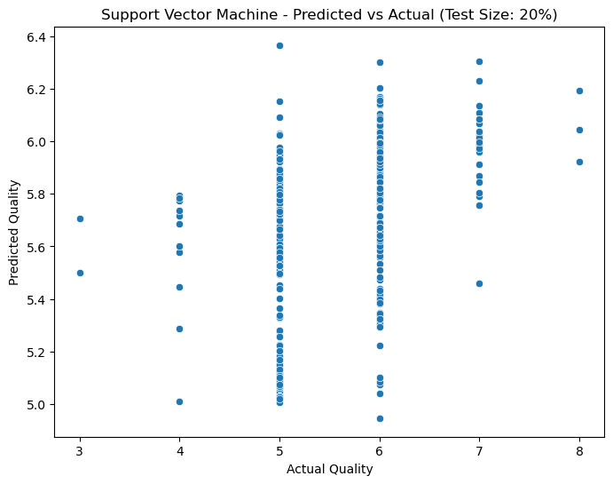

```python
plt.figure(figsize=(8, 6))
sns.scatterplot(x=y_test, y=pred_y)
plt.title(f"{reg_name} - Predicted vs Actual (Test Size: {test_size:.0%})")
plt.xlabel("Actual Quality")
plt.ylabel("Predicted Quality")
plt.show()
```

## Regression Model Performance Summary for Vinho Verde Wine Quality Prediction

In the pursuit of unraveling physicochemical attributes influencing Vinho Verde wine quality and developing predictive models for quality estimation and enhancement, regression algorithms were evaluated using different testing data sizes. Here is a summary of the performance metrics for significant variables across various models:

1. Decision Tree:

Mean Squared Error (MSE): Ranged from 0.6050 to 0.6538 Root Mean Squared Error (RMSE): Ranged from 0.7778 to 0.8085 Mean Absolute Error (MAE): Varied from 0.4500 to 0.5062 R-squared (R²): Showed mixed trends, including negative values, indicating challenges in explaining data variability.

1. Random Forest:

1. Linear Regression:

MSE: Consistently lower than Decision Tree but higher than Random Forest, ranging from 0.3845 to 0.4282 RMSE: Ranged from 0.6201 to 0.6544 MAE: Exhibited a moderate range, ranging from 0.4696 to 0.5073 R²: Showed a positive trend, indicating a reasonable fit to the data.

1. K-Nearest Neighbors (KNN):

MSE: Varied from 0.5300 to 0.5656, showing moderate performance RMSE: Ranged from 0.7280 to 0.7521 MAE: Showed a higher range, ranging from 0.5670 to 0.5900 R²: Indicated a mixed trend, including positive values but with lower consistency.

1. Support Vector Machine (SVM):

MSE: Ranged from 0.4743 to 0.5399, demonstrating competitive performance RMSE: Varied from 0.6887 to 0.7348 MAE: Showed a moderate range, ranging from 0.5187 to 0.5484 R²: Indicated a positive trend, suggesting a reasonable fit.

**Overall Recommendation:**

Among the models, Random Forest consistently outperformed others, showcasing lower MSE, RMSE, and higher R² values. Linear Regression also presented reasonable performance, demonstrating a balance between model simplicity and accuracy. Decision Tree exhibited challenges in explaining data variability, leading to negative R² values. KNN and SVM demonstrated moderate performance, with variations in predictive accuracy. In conclusion, for Vinho Verde wine quality prediction, the Random Forest model emerges as a promising choice, balancing predictive accuracy and robustness across various testing data sizes.

## More on Findings From Data Analysis Sub-section Questions and Visualization

In pursuit of understanding the factors influencing Vinho Verde wine quality, key findings emerged. The average alcohol content was approximately 10.42, while a significant negative correlation of -0.54 was observed between citric acid and pH. The maximum residual sugar content reached 15.5, contributing to the overall composition. In terms of quality prediction, wines with low volatile acidity exhibited an average quality of approximately 6.20, and 18 wines in the dataset received a quality rating above 7. The relationship between density and alcohol content revealed a negative correlation of -0.50, offering insights into their combined impact on quality.

#### References

- (Data Source URL: https://www.kaggle.com/datasets/uciml/red-wine-quality-cortez-et-al-2009/code?datasetId=4458) by UCI MACHINE LEARNING